# EDA & CDA of touch data

HY

2025-05-31

### 実習：R言語による行動データ解析

行動データをR言語で解析する流れを触覚実験のデータを対象に実習します。

1. データの入力と確認
2. [探索的データ解析](https://dictionary.apa.org/exploratory-data-analysis)：可視化 - 主観的等価点 - 観察者間平均、標準誤差 - 心理測定関数
3. [確証的データ解析](https://dictionary.apa.org/confirmatory-data-analysis)：線形モデリング - ロジスティック回帰, 一般化線形混合効果モデル - モデル比較

### 0. 準備

作業ディレクトリをこのスクリプトファイルがある場所に移動します。Rstudioのメニューで、Session、Set Working directory、To source file locationの順にクリックして下さい。 その後、コードを実行していきます。

Rの実行環境を初期化（変数の除去）した後、解析に必要なライブラリを読み込みます。

このファイルをRstudioで開くと、灰色領域にコードが表示されます。これを実行するには、右上の小さな緑三角(playボタン)を押します。すべてのコードを一気に実行するには、タブメニューのKnit(青色)をクリックします。

```r
rm(list=ls(all=TRUE)) # remove variables

# load libraries to be used
library(tidyverse) # modern R
```

```r
library(ggExtra) # extra plotting functions
library(cowplot) # to arrange plots
library(viridis) # color maps
library(R.matlab) # to read MAT files
library(quickpsy) # psychometric functions
library(lmerTest) # linear mixed effects models
library(emmeans) # posthoc analysis for linear modeling
library(MuMIn) # model comparison
library(effects) # effect display for linear models
library(performance) # to check collinearity (correlations between predictors)
library(knitr) # formatting
library(papaja) # Preparing APA Journal Articles format
```

### 1. データの入力と確認

実験データは[整然データ](https://r4ds.hadley.nz/data-tidy.html)の形式でCSV(Comma-Separated

Values)ファイルで保存するように心がけて下さい。縦に長くなるのでロング形式とも呼ばれます。心理実検の場合、各行が各試行の実験条件と被験者応答になります。read_csv関数でファイル（ディレクトリとファイル名：パス）を指定して、[データフレーム](https://tibble.tidyverse.org/) dat として読み込みます。“./”はカレントディレクトリ、#“はコメント行を示しています。

```r
# load all subjects' data
# - csv (comma separated values) file
# - long format: each row contains each trial data(conditions, responses)
ifn <- "./touch_all_observers.csv"
dat <- read_csv(ifn)
```

多くの列（変数）がありますが、今回は４つの刺激条件（テスト刺激の周波数と振幅、参照刺激の周波数と振幅）、被験者の回答（テストのピッチの方が高ければ１、そうでなければ０）、被験者ID、試行ID、ステアケースID、回答の反転に注目します。

```r
# independent variables (main predictors):
#   test frequency(test_freq), reference frequency(ref_freq)
#   test amplitude(test_amp), reference amplitude(ref_amp)
# dependent variable: correct, 1(0): test pitch >(<) reference pitch
#
# sub:  subject's id
# trial_id: Nth trial
# staircase: staircase id, double random staircase method
# reversal: response reversal(1) or not(0)

## check the data, variable types?
glimpse(dat)
```

```
## Rows: 17,370
## Columns: 36
## $ sub_name           <chr> "subj_01", "subj_01", "subj_01", "subj_01", "subj_0…
## $ sub                <dbl> 1, 1, 1, 1, 1, 1, 1, 1, 1, 1, 1, 1, 1, 1, 1, 1, 1, …
## $ session            <dbl> 1, 1, 1, 1, 1, 1, 1, 1, 1, 1, 1, 1, 1, 1, 1, 1, 1, …
## $ body_part          <chr> "R_indexfinger", "R_indexfinger", "R_indexfinger", …
## $ hf_type            <chr> "pusS1", "pusS1", "pusS1", "pusS1", "pusS1", "pusS1…
## $ hf_used            <chr> "'S7'", "'S7'", "'S7'", "'S7'", "'S7'", "'S7'", "'S…
## $ hf_model           <chr> "'S7'", "'S7'", "'S7'", "'S7'", "'S7'", "'S7'", "'S…
## $ trial_id           <dbl> 1, 2, 3, 4, 5, 6, 7, 8, 9, 10, 11, 12, 13, 14, 15, …
## $ run                <dbl> 5, 5, 5, 5, 5, 5, 5, 5, 5, 5, 5, 5, 5, 5, 5, 5, 5, …
## $ cond               <chr> "rf160_ra281_ta281", "rf160_ra281_ta281", "rf160_ra…
## $ staircase          <dbl> 5, 15, 15, 5, 5, 5, 5, 15, 5, 5, 5, 15, 5, 15, 15, …
## $ ref_freq           <dbl> 160, 160, 160, 160, 160, 160, 160, 160, 160, 160, 1…
## $ ref_amp            <dbl> 2.8062, 2.8062, 2.8062, 2.8062, 2.8062, 2.8062, 2.8…
```

[output cut: 23 more lines]

```r
## factor type data
dat$sub <- as.factor(dat$sub)
glimpse(dat)
```

```
## Rows: 17,370
## Columns: 36
## $ sub_name           <chr> "subj_01", "subj_01", "subj_01", "subj_01", "subj_0…
## $ sub                <fct> 1, 1, 1, 1, 1, 1, 1, 1, 1, 1, 1, 1, 1, 1, 1, 1, 1, …
## $ session            <dbl> 1, 1, 1, 1, 1, 1, 1, 1, 1, 1, 1, 1, 1, 1, 1, 1, 1, …
## $ body_part          <chr> "R_indexfinger", "R_indexfinger", "R_indexfinger", …
## $ hf_type            <chr> "pusS1", "pusS1", "pusS1", "pusS1", "pusS1", "pusS1…
## $ hf_used            <chr> "'S7'", "'S7'", "'S7'", "'S7'", "'S7'", "'S7'", "'S…
## $ hf_model           <chr> "'S7'", "'S7'", "'S7'", "'S7'", "'S7'", "'S7'", "'S…
## $ trial_id           <dbl> 1, 2, 3, 4, 5, 6, 7, 8, 9, 10, 11, 12, 13, 14, 15, …
## $ run                <dbl> 5, 5, 5, 5, 5, 5, 5, 5, 5, 5, 5, 5, 5, 5, 5, 5, 5, …
## $ cond               <chr> "rf160_ra281_ta281", "rf160_ra281_ta281", "rf160_ra…
## $ staircase          <dbl> 5, 15, 15, 5, 5, 5, 5, 15, 5, 5, 5, 15, 5, 15, 15, …
## $ ref_freq           <dbl> 160, 160, 160, 160, 160, 160, 160, 160, 160, 160, 1…
## $ ref_amp            <dbl> 2.8062, 2.8062, 2.8062, 2.8062, 2.8062, 2.8062, 2.8…
```

[output cut: 23 more lines]

データフレーム dat をsummary関数入力すると、各列の要約統計量が表示されます。因子型に指定したsubの場合、各被験者のIDとデータ（行）数、つまり、試行数が表示されます。

```r
## summary statistics
summary(dat)
```

```
##    sub_name              sub          session   body_part
##  Length:17370       7      :1313   Min.   :1   Length:17370
##  Class :character   14     :1277   1st Qu.:1   Class :character
##  Mode  :character   15     :1265   Median :1   Mode  :character
##                     2      :1244   Mean   :1
##                     5      :1211   3rd Qu.:1
##                     11     :1203   Max.   :1
##                     (Other):9857
##    hf_type            hf_used            hf_model            trial_id
##  Length:17370       Length:17370       Length:17370       Min.   :  1.0
##  Class :character   Class :character   Class :character   1st Qu.:145.0
##  Mode  :character   Mode  :character   Mode  :character   Median :290.0
##                                                           Mean   :293.1
##                                                           3rd Qu.:435.0
##                                                           Max.   :716.0
##
##       run             cond             staircase        ref_freq
##  Min.   : 1.000   Length:17370       Min.   : 1.00   Min.   :160
##  1st Qu.: 3.000   Class :character   1st Qu.: 5.00   1st Qu.:200
##  Median : 5.000   Mode  :character   Median :10.00   Median :280
##  Mean   : 5.452                      Mean   :10.34   Mean   :245
##  3rd Qu.: 8.000                      3rd Qu.:15.00   3rd Qu.:320
##  Max.   :10.000                      Max.   :20.00   Max.   :320
##
##     ref_amp      ref_amp_corrected    ref_samp       ref_svolt
##  Min.   :2.806   Min.   :2.717     Min.   :1.508   Min.   :0.5586
##  1st Qu.:2.806   1st Qu.:2.722     1st Qu.:2.111   1st Qu.:1.1057
##  Median :2.806   Median :2.805     Median :5.284   Median :1.8533
##  Mean   :2.806   Mean   :2.774     Mean   :4.375   Mean   :2.1674
##  3rd Qu.:2.806   3rd Qu.:2.807     3rd Qu.:6.355   3rd Qu.:2.9540
##  Max.   :2.806   Max.   :2.810     Max.   :8.762   Max.   :5.8218
##                                    NA's   :3       NA's   :3
##     ref_volt       test_freq         test_amp     test_amp_corrected
##  Min.   :7.157   Min.   : 83.91   Min.   :1.750   Min.   :1.662
##  1st Qu.:7.752   1st Qu.:175.30   1st Qu.:2.216   1st Qu.:2.127
##  Median :8.383   Median :242.56   Median :2.806   Median :2.723
##  Mean   :8.227   Mean   :294.13   Mean   :2.876   Mean   :2.844
##  3rd Qu.:8.699   3rd Qu.:384.66   3rd Qu.:3.553   3rd Qu.:3.553
##  Max.   :9.313   Max.   :585.50   Max.   :4.500   Max.   :4.506
##
```

[output cut: 17 more lines]

```
##  Min.   :1.000   Min.   :0.0000   Min.   :0.0000   Min.   :0.0000
##  1st Qu.:1.000   1st Qu.:0.0000   1st Qu.:0.0000   1st Qu.:0.0000
##  Median :2.000   Median :0.0000   Median :1.0000   Median :0.0000
##  Mean   :1.513   Mean   :0.4242   Mean   :0.5161   Mean   :0.3965
##  3rd Qu.:2.000   3rd Qu.:1.0000   3rd Qu.:1.0000   3rd Qu.:1.0000
##  Max.   :2.000   Max.   :1.0000   Max.   :1.0000   Max.   :1.0000
##
##   temparature      time_stamp            day            trial
##  Min.   :23.12   Min.   :2.02e+13   Min.   :1.000   Min.   :   1.0
##  1st Qu.:28.00   1st Qu.:2.02e+13   1st Qu.:1.000   1st Qu.: 290.0
##  Median :28.41   Median :2.02e+13   Median :2.000   Median : 579.5
##  Mean   :28.22   Mean   :2.02e+13   Mean   :1.509   Mean   : 583.5
##  3rd Qu.:28.81   3rd Qu.:2.02e+13   3rd Qu.:2.000   3rd Qu.: 869.0
##  Max.   :29.76   Max.   :2.02e+13   Max.   :2.000   Max.   :1313.0
##
```

実験条件を確認します。まず、主たる変数だけ選択(select)して、要約統計量(summary)を形式を整えて(kable)表示します。[パイプオペレータ:%>%](https://r4ds.had.co.nz/pipes.html)を使っている点に注意して下さい。 被験者(sub)によって試行数が異なること、参照刺激の振幅(ref_amp)が一定値であるなど、気づきます。

```r
# %>%: pipe operator, to remove interim variables
# a <- select(dat, sub, test_freq, test_amp, ref_freq, ref_amp)
# plot(a)
dat %>%
  select(sub, test_freq, test_amp, ref_freq, ref_amp) %>%
  summary() %>%
  kable()
```

|  | sub | test_freq | test_amp | ref_freq | ref_amp |
| --- | --- | --- | --- | --- | --- |
|  | 7 :1313 | Min. : 83.91 | Min. :1.750 | Min. :160 | Min. :2.806 |
|  | 14 :1277 | 1st Qu.:175.30 | 1st Qu.:2.216 | 1st Qu.:200 | 1st Qu.:2.806 |
|  | 15 :1265 | Median :242.56 | Median :2.806 | Median :280 | Median :2.806 |
|  | 2 :1244 | Mean :294.13 | Mean :2.876 | Mean :245 | Mean :2.806 |
|  | 5 :1211 | 3rd Qu.:384.66 | 3rd Qu.:3.553 | 3rd Qu.:320 | 3rd Qu.:2.806 |
|  | 11 :1203 | Max. :585.50 | Max. :4.500 | Max. :320 | Max. :2.806 |
|  | (Other):9857 | NA | NA | NA | NA |

plot()すると、実験条件がよくわかります。テスト刺激(test_amp)の振幅 が5段階、周波数は連続的に変化、参照刺激の振幅は1段階で固定、周波数(ref_freq)は4段階、全員が同じ条件（被験者内比較の実験デザイン）であることがわかります。

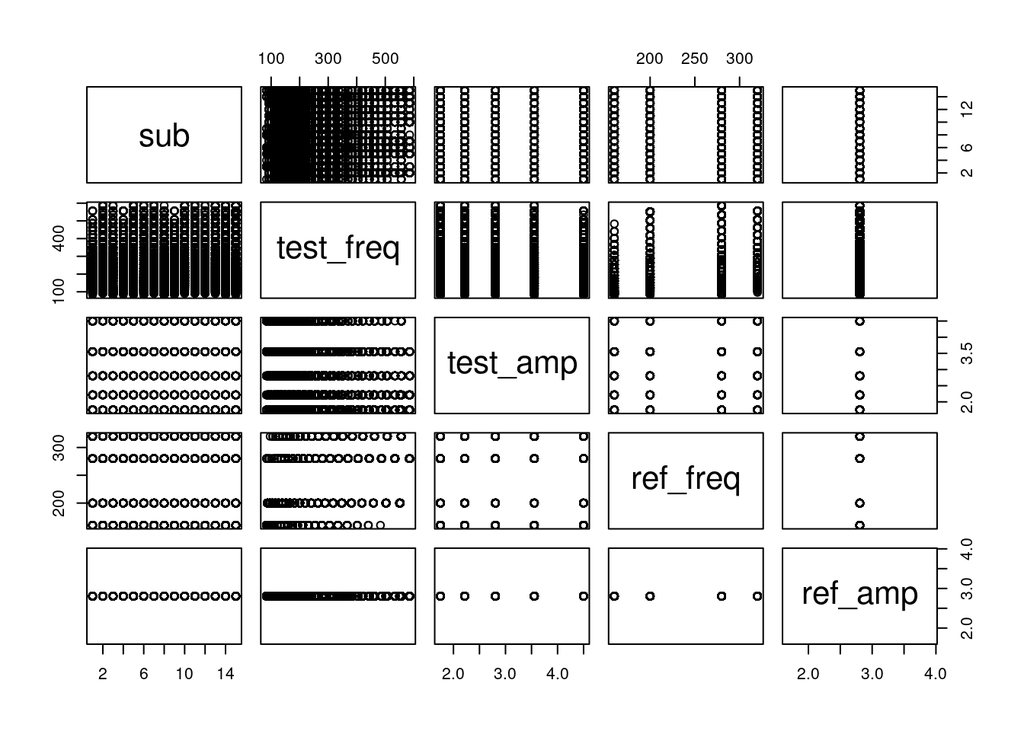

```r
dat %>%
  select(sub, test_freq, test_amp, ref_freq, ref_amp) %>%
  plot()
```

そこで、参照刺激とテスト刺激の具体的な値（水準）を変数に代入すると同時に表示します。式全体をカッコでくくると代入結果が表示されます。周波数の単位はHz、振幅の単位はμmです。

```r
## reference/test levels
(ref_freq <- unique(dat$ref_freq))
```

```
## [1] 160 200 320 280
```

```r
(ref_amp <- unique(dat$ref_amp))
```

```
## [1] 2.8062
```

```r
(test_amp <- unique(dat$test_amp))
```

```
## [1] 2.8062 1.7500 3.5534 2.2160 4.4997
```

昇順に並べ替え(sort)ます。

```r
(ref_freq <- sort(ref_freq))
```

```
## [1] 160 200 280 320
```

```r
(test_amp <- sort(test_amp))
```

```
## [1] 1.7500 2.2160 2.8062 3.5534 4.4997
```

### 3. 探索的データ解析（Exploratory Data Analysis, EDA）

#### 主観的等価点(PSE, point of subjective equality)

この実験では、人差し指腹部に正弦波の振動刺激を短時間（500ミリ秒）呈示して、ピッチ（周波数の高低）の知覚に振動振幅が及ぼす影響を２肢強制選択課題で調べています。各試行では、刺激が２回、少し間をおいて呈示されます。どちらか一方が参照刺激で他方がテスト刺激で、順番はランダムです。被験者は１回目と２回目のどちらのピッチが高かったかをボタン押しで回答しました。参照刺激の振幅は固定（2.8062 μm)で、周波数は4種の周波数(160, 200, 280, 320Hz)のいずれかでした。テストの振幅は5種で参照刺激と同じ振幅および大小各２種でした(1.7500 2.2160 2.8062 3.5534 4.4997)。テストの振幅が参照刺激の振幅と同じ条件では、テストの周波数が参照刺激の周波数に等しいと同一の刺激になるので、両者に対する周波数の知覚（ピッチ）が等しくなり、課題の成績はチャンスレベルになるはずです。この時の周波数を主観的等価点（PSE）と呼びます。もし、振幅が大きくなるとピッチが主観的には高く感じられるならば、テストの振幅が参照刺激より大きい場合、主観的等価点は参照刺激より低い周波数になると予想されます。

PSEを決定するためには様々なテスト周波数を試す必要があります。この実験では、テストの周波数は被験者の応答に応じて[階段法](https://dictionary.apa.org/staircase-method)に従って少しづつ変えています。被験者の応答が反転したとき、reversal変数を1とし、規定回数を超えたら階段系列は終了します。PSE付近になると反転が頻発するので、反転回数を数えて、最後数回の反転時の周波数の平均をとってPSEとします。

以下、参照刺激が160Hzの条件について、５つのテスト振幅条件についてPSEを求めます。 参照刺激が160Hzのデータだけを抜き出してtdat(target data)に格納します。

```r
(tgt_ref_freq <- ref_freq[1])
```

```
## [1] 160
```

```r
tdat <- dat %>%
  filter(ref_freq == tgt_ref_freq)
```

反転回数を数えます。reversalが１の行（filter）、主たる変数の列（select）を抜き出したうえで、昇順に並べ替えて rev_dat とします。さらに、同じ被験者・参照刺激周波数・テスト振幅ごとにグルーピングしまなす（group_by）。グループ内の行番号が反転回数に等しくなるので、それを変数occurにセットします。

```r
# pull out reversal data
rev_dat <- tdat %>%
  filter(reversal == 1) %>%
  select(sub, ref_freq, ref_amp, test_amp, test_freq, trial_id) %>%
  arrange(sub, ref_freq, ref_amp, test_amp, trial_id)

# count the reversals
# for each subject and condition
rev_dat <- rev_dat %>%
  group_by(sub, ref_freq, test_amp) %>% # for each condition
  mutate(occur = row_number())
```

最後に、18回目の反転以降のデータを抜き出して（filter）、データ数 n とテスト周波数の平均値を求め（summarise）、書式を整えて表示します（kable）。match_freqが各被験者のPSEになります。

```r
oc <- 18
pse <- rev_dat %>%
  filter(occur >= oc) %>%
  summarise(n=n(), match_freq = mean(test_freq))
pse %>% kable()
```

| sub | ref_freq | test_amp | n | match_freq |
| --- | --- | --- | --- | --- |
| 1 | 160 | 1.7500 | 7 | 199.7371 |
| 1 | 160 | 2.2160 | 7 | 155.1920 |
| 1 | 160 | 2.8062 | 7 | 152.6021 |
| 1 | 160 | 3.5534 | 7 | 141.1702 |
| 1 | 160 | 4.4997 | 7 | 133.6546 |
| 2 | 160 | 1.7500 | 7 | 215.0310 |
| 2 | 160 | 2.2160 | 7 | 224.0724 |
| 2 | 160 | 2.8062 | 7 | 170.3502 |
| 2 | 160 | 3.5534 | 7 | 134.1500 |
| 2 | 160 | 4.4997 | 7 | 129.8201 |
| 3 | 160 | 1.7500 | 7 | 145.2418 |
| 3 | 160 | 2.2160 | 7 | 145.0461 |
| 3 | 160 | 2.8062 | 7 | 177.5259 |
| 3 | 160 | 3.5534 | 7 | 178.2892 |
| 3 | 160 | 4.4997 | 7 | 157.2851 |
| 4 | 160 | 1.7500 | 7 | 231.7164 |
| 4 | 160 | 2.2160 | 7 | 197.9977 |
| 4 | 160 | 2.8062 | 7 | 158.5105 |
| 4 | 160 | 3.5534 | 7 | 135.1584 |
| 4 | 160 | 4.4997 | 7 | 115.6553 |
| 5 | 160 | 1.7500 | 7 | 217.3609 |
| 5 | 160 | 2.2160 | 7 | 206.5755 |
| 5 | 160 | 2.8062 | 7 | 144.0831 |
| 5 | 160 | 3.5534 | 7 | 152.6708 |
| 5 | 160 | 4.4997 | 7 | 135.6541 |
| 6 | 160 | 1.7500 | 7 | 253.4503 |
| 6 | 160 | 2.2160 | 7 | 240.6035 |
| 6 | 160 | 2.8062 | 7 | 180.7469 |
| 6 | 160 | 3.5534 | 7 | 240.7093 |
| 6 | 160 | 4.4997 | 7 | 129.0826 |
| 7 | 160 | 1.7500 | 7 | 214.4089 |
| 7 | 160 | 2.2160 | 7 | 185.4912 |
| 7 | 160 | 2.8062 | 7 | 154.2712 |
| 7 | 160 | 3.5534 | 7 | 130.4925 |
| 7 | 160 | 4.4997 | 7 | 118.7292 |
| 8 | 160 | 1.7500 | 7 | 204.9706 |
| 8 | 160 | 2.2160 | 7 | 142.3685 |
| 8 | 160 | 2.8062 | 7 | 155.1974 |
| 8 | 160 | 3.5534 | 7 | 302.3437 |
| 8 | 160 | 4.4997 | 7 | 146.4579 |
| 9 | 160 | 1.7500 | 7 | 216.8608 |
| 9 | 160 | 2.2160 | 7 | 164.8851 |
| 9 | 160 | 2.8062 | 7 | 156.4970 |
| 9 | 160 | 3.5534 | 7 | 158.5363 |
| 9 | 160 | 4.4997 | 7 | 128.9638 |
| 10 | 160 | 1.7500 | 7 | 204.0362 |
| 10 | 160 | 2.2160 | 7 | 200.4479 |
| 10 | 160 | 2.8062 | 7 | 173.7924 |
| 10 | 160 | 3.5534 | 7 | 150.4154 |
| 10 | 160 | 4.4997 | 7 | 124.2183 |
| 11 | 160 | 1.7500 | 7 | 212.9172 |
| 11 | 160 | 2.2160 | 7 | 185.2000 |
| 11 | 160 | 2.8062 | 7 | 152.8064 |
| 11 | 160 | 3.5534 | 7 | 161.8604 |
| 11 | 160 | 4.4997 | 7 | 127.6820 |
| 12 | 160 | 1.7500 | 7 | 221.1119 |
| 12 | 160 | 2.2160 | 7 | 151.8391 |
| 12 | 160 | 2.8062 | 7 | 169.3502 |
| 12 | 160 | 3.5534 | 7 | 118.3993 |
| 12 | 160 | 4.4997 | 7 | 128.5666 |
| 13 | 160 | 1.7500 | 7 | 238.3315 |
| 13 | 160 | 2.2160 | 7 | 192.7155 |
| 13 | 160 | 2.8062 | 7 | 160.3048 |
| 13 | 160 | 3.5534 | 7 | 128.0201 |
| 13 | 160 | 4.4997 | 7 | 110.9422 |
| 14 | 160 | 1.7500 | 7 | 302.3081 |
| 14 | 160 | 2.2160 | 7 | 217.6411 |
| 14 | 160 | 2.8062 | 7 | 215.0916 |
| 14 | 160 | 3.5534 | 7 | 144.5633 |
| 14 | 160 | 4.4997 | 7 | 108.2823 |
| 15 | 160 | 1.7500 | 7 | 203.8953 |
| 15 | 160 | 2.2160 | 7 | 168.6985 |
| 15 | 160 | 2.8062 | 7 | 161.3688 |
| 15 | 160 | 3.5534 | 7 | 156.1839 |
| 15 | 160 | 4.4997 | 7 | 109.3629 |

PSEのグラフをggplot関数で作ります。グラフの横軸をPSE、縦軸をテストの振幅にします（aes, aesthetic）。参照刺激の周波数ごとに異なる色の折れ線グラフを追加します(geom_path)。その上にデータ点（PSE）を打ちます（geom_point）。参照刺激の周波数を示す垂直線（geom_vline）と参照刺激の振幅を示す水平線（geom_hline）を追加します。以上のグラフを被験者ごとにパネルを分けて(facet_wrap）描きます（plot）。

ofnで指定したファイル名でグラフを保存します。ggsaveは引数がない場合、直前のプロットを保存します。 大半の観察者で、PCEは振幅が大きくなるとより低周波数になっています。

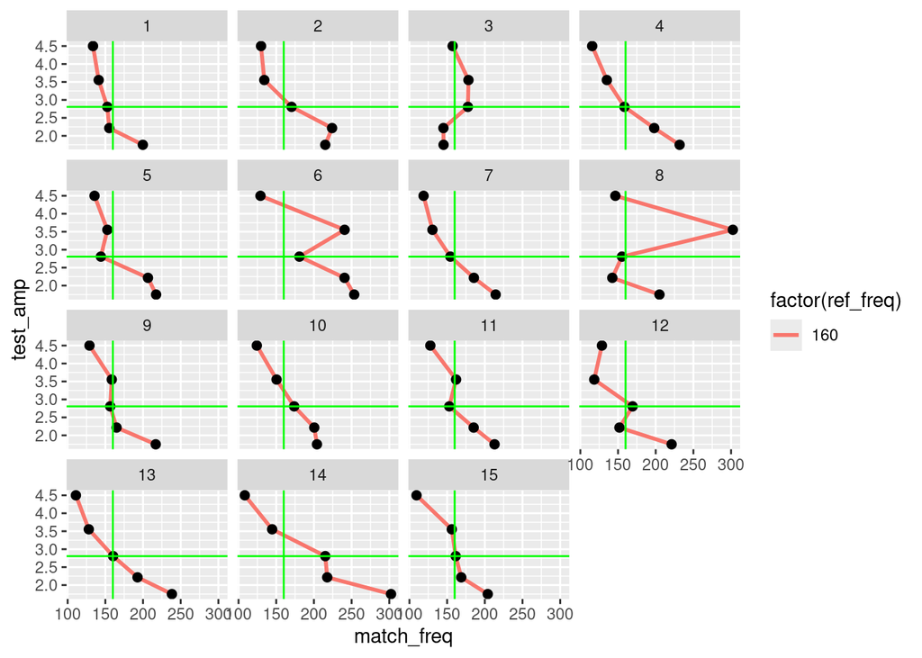

```r
gp11 <- ggplot(pse, aes(x = match_freq, y = test_amp)) +
  geom_path(linewidth=1, aes(group=ref_freq, colour=factor(ref_freq))) +
  geom_point(size=2) +
  geom_vline(xintercept = tgt_ref_freq, colour="green") +
  geom_hline(yintercept = ref_amp, colour="green") +
  facet_wrap(~sub)
print(gp11)
```

```r
ofn <- sprintf("equal_pitch_curve_%d.jpg", tgt_ref_freq)
ggsave(ofn)
```

両軸を対数軸にして(scale_x(y)_log10)にして、回帰直線を引いてみます。 大半の観察者で直線でうまく回帰できているようです。

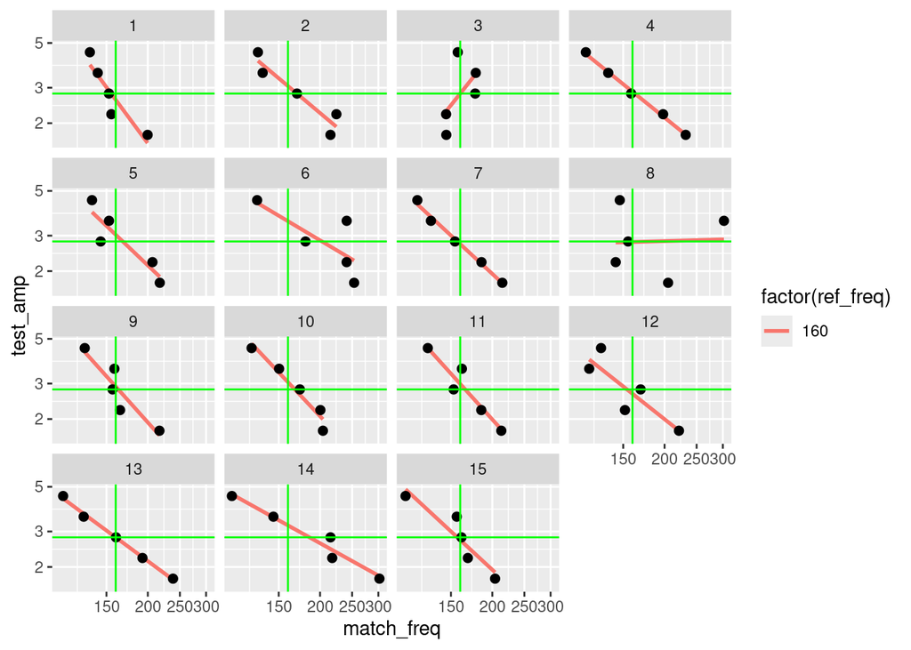

```r
gp12 <- ggplot(pse, aes(x = match_freq, y = test_amp)) +
  geom_smooth(method="lm", se=FALSE, linewidth=1, aes(group=ref_freq, colour=factor(ref_freq))) +
  geom_point(size=2) +
  geom_vline(xintercept = tgt_ref_freq, colour="green") +
  geom_hline(yintercept = ref_amp, colour="green") +
  scale_x_log10() +
  scale_y_log10() +
  facet_wrap(~sub)
print(gp12)
```

```r
ofn <- sprintf("equal_pitch_curve_log_%d.jpg", tgt_ref_freq)
ggsave(ofn)
```

#### 心理測定関数(psychometric function)

主観的等価点ではテスト刺激を選択する確率が50%付近の試行だけに注目しましたが、すべての試行を使えば、選択率が25%や75%等になる点（テストの周波数）を推定することができます。選択率を実験パラメーターの関数として表現したものを[心理測定関数](https://dictionary.apa.org/psychophysical-function)と呼びます。心理測定関数の測定には、[恒常法](https://dictionary.apa.org/method-of-constant-stimuli)が使われる場合が多いですが、階段法でも可能です。ここでは、[ロジスティック回帰](https://dictionary.apa.org/logistic-regression)の枠組みで、quickpsy関数を使って、心理測定関数を求めてみます。

被験者ごとに心理測定関数を推定するために、for文を使って、quickpsy関数を繰り返し実行し、分析結果をfitに格納します。これを可視化(plot)して、画像として保存します(ggsave)。quickpsy関数の使い方は[マニュアル](https://www.rdocumentation.org/packages/quickpsy/versions/0.1.5.1/topics/quickpsy)を参照して下さい。この計算には少し時間かかります（数分）。大半の観察者で、振幅が大きいほど心理測定関数が左側にシフトしています。

```r
#####################################
# psychometric function
#  by quickpsy()
#####################################
(sub <- sort(unique(dat$sub)))
```

```
##  [1] 1  2  3  4  5  6  7  8  9  10 11 12 13 14 15
## Levels: 1 2 3 4 5 6 7 8 9 10 11 12 13 14 15
```

```r
# sub3,8,6: bad convergences?
for(s in sub){
  fdat <- dplyr::filter(tdat, sub == s)
  fit <- quickpsy(fdat, test_freq, correct, guess=0.0,
                   grouping = c("test_amp"),
                   ci = 0.75, # confidence interval: 75%
                   fun = logistic_fun, bootstrap = 'nonparametric')
  plot(fit,  ci = TRUE, thresholds = TRUE)
  ggsave(sprintf("sub%s_pychometric_%d.jpg", s, tgt_ref_freq))
}
```

### 4. 確証的データ解析（Confirmatory Data Analysis, CDA）

探索的なデータ解析によって、ピッチ感は振動刺激の周波数だけではなく、振幅にも影響され、振幅が大きいほどピッチ感は高くなることがわかりました。

以下、これを統計的に確かめます。従来は[分散分析](https://dictionary.apa.org/analysis-of-variance)が主流でしたが、最近は、[回帰分析](https://dictionary.apa.org/regression-analysis)の枠組みで、[一般化線形混合モデル(GLMM, Genralized Linear Mixed effects Models)](https://journals.sagepub.com/doi/full/10.1177/2515245920960351)を使うのが主流になりつつあります。計算負荷は増大しますが、多くのメリットがあります。ここではGLMMを用いて分析します。

GLMMでは、観察者の反応（目的変数）を実験条件（予測変数）の重み付き線形加算に基づいて予測します。今回の場合、テストと参照刺激の周波数と振幅から、観察者がどちらを高ピッチとして選ぶかを予測します。

#### 可視化(EDA)

モデリングを作る前に、まず、予測変数と観察者の反応（2値,1:テスト刺激が高ピッチ 0:参照刺激が高ピッチ）の関係を可視化します。（探索的データ解析）

まず、予測変数の対数をとります。PSEの両対数グラフが直線でうまく回帰できたからです。このことは予測変数の対数をとれば、GLMMの枠組みで、つまり、それらの線形加算でピッチ感を予測できることを示唆しています。加えて、振幅と周波数に関して、テストと参照刺激の対数軸上の差（d_freq, d_amp） を計算します。これらの差の線形加算がピッチの高低を左右するのでは？という仮説です。

```r
################################################
## effects of ref_amp and test_amp on response
################################################
dat <- dat %>%
  mutate(log_ref_amp = log10(ref_amp),
         log_test_amp = log10(test_amp)) %>%
  mutate(d_amp = log_test_amp - log_ref_amp) %>%
  mutate(d_freq = log10(test_freq) - log10(ref_freq))
```

すべての周波数条件（160, 200, 280, 320Hz）を区別せずにまとめた上で、参加者全員の反応を見てみます。tgt_ref_freq<-c(160,200)など、一部の周波数だけをセットすれば、周波数ごとに分析することができます。興味があれば、やってみてください。傾向に大差はないですが、後の解析によると少し違いがあるようです。

```r
# for all reference frequencies
# target data
(tgt_ref_freq <-  ref_freq)
```

```
## [1] 160 200 280 320
```

```r
tdat <- filter(dat, ref_freq %in% tgt_ref_freq)
```

##### 同じ振幅の場合

まず、テストの振幅が参照刺激と等しい時のデータの傾向を見ます。 対象データを抜き出すために、振幅の差 d_amp の分布を確認します。

```r
# test amp == ref amp
test_amp
```

```
## [1] 1.7500 2.2160 2.8062 3.5534 4.4997
```

```r
ref_amp
```

```
## [1] 2.8062
```

```r
test_amp/ref_amp
```

```
## [1] 0.6236191 0.7896800 1.0000000 1.2662676 1.6034851
```

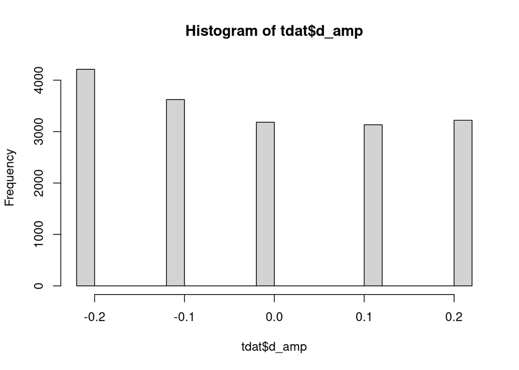

```r
hist(tdat$d_amp)
```

d_amp に基づいて、所存のデータを tdat.d0に抜き出します。そして、この時のテストと参照刺激の周波数差の分布 hist を表示します。同じ刺激なので０を平均とする正規分布に近いデータになるはずです。

```r
tdat.d0 <-  tdat %>%
  filter(d_amp >- 0.05 & d_amp < 0.05)
range(tdat.d0$d_amp)
```

```
## [1] 0 0
```

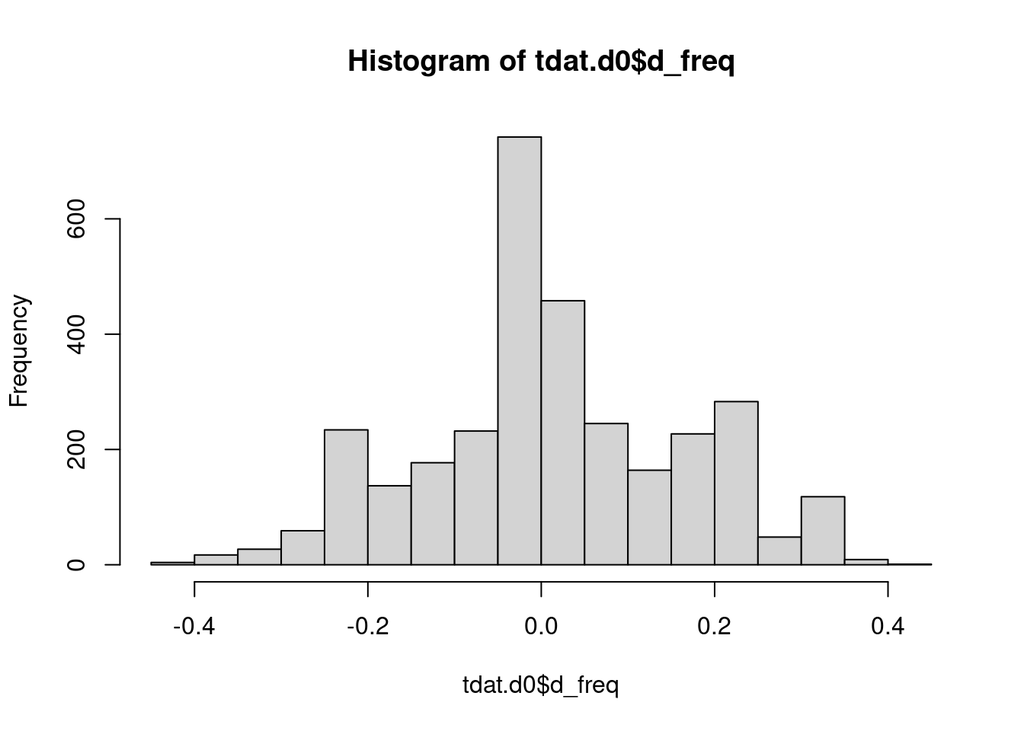

```r
hist(tdat.d0$d_freq)
```

観察者の反応レベル(correct:0 or 1）ごとに分布を見てみます。周波数に差がないときに、反応が五分五分になっています。同じ刺激なので、予想通りです。実験に問題はなさそうです。

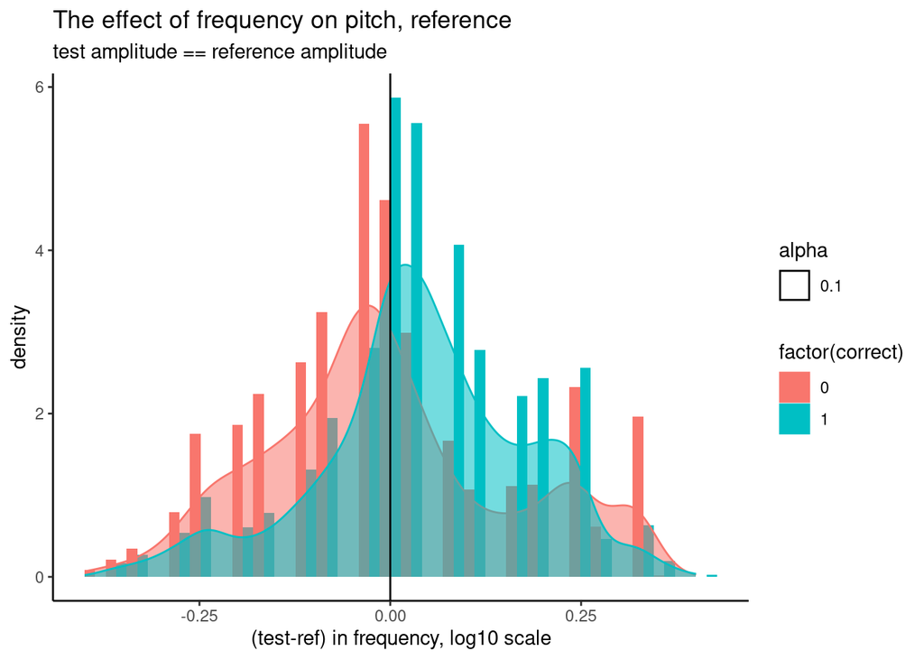

```r
# test amplitude == reference amplitude
gp20 <- ggplot(tdat.d0,
               aes(x = d_freq, fill = factor(correct))) +
  geom_histogram(aes(y = ..density..), position = "dodge") +
  geom_density(aes(color =  factor(correct), alpha = 0.1)) +
  geom_vline(xintercept = 0, colour = "black") +
  labs(title = "The effect of frequency on pitch, reference",
       subtitle = "test amplitude == reference amplitude",
       x = "(test-ref) in frequency, log10 scale") +
  theme_classic()
print(gp20)
```

##### 異なる振幅の場合

テストの振幅が参照刺激と異なる場合も含めて、反応の分布を見てみます。 参照刺激の周波数ごとに、反応と振幅差（d_amp）、周波数差（d_freq）の関係を可視化します。横軸を周波数差、縦軸を振幅差として反応の散布図を描いて、描画オブジェクトgp21~24に保存します。４つの周波数の結果がひと目で比較できるように、一つのプロットとして表示します（plot_grid）。

全被験者の全試行を可視化したものです。各点が各試行の観察者の反応で、青が１（テストピッチ＞参照ピッチ）、赤が０（テストピッチ＜参照ピッチ）です。ピッチ感が周波数だけで決まるなら、テストが高ピッチに感じるのは、d_ampによらず、d_freq > 0になるはずです。つまり、散布図はd_freq = 0の垂直線を堺に、右に青（１），左に赤（０）の点が分布するはずです。結果はそうではなくて、ピッチ感が振幅にも依存していることが明確です。青と赤の分布の境界（主観的等価点）は、原点（同一の刺激）を通る右肩下がりの直線に沿っており、周波数間でその傾きに大差はないように見えます。

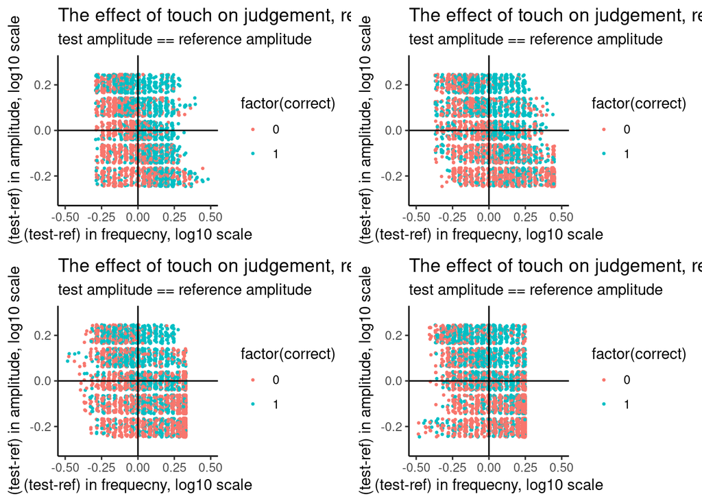

```r
# all test amplitudes
gp21 <- ggplot(filter(tdat, ref_freq == 160),
               aes(y = d_amp, x = d_freq, colour = factor(correct))) +
  geom_jitter(width = 0.01, size = 0.5) +
  geom_vline(xintercept = 0, colour = "black") +
  geom_hline(yintercept = 0, colour = "black") +
  ylim(c(-0.3, 0.3)) +
  xlim(c(-0.5, 0.5)) +
  labs(title = "The effect of touch on judgement, reference: 160 Hz",
       subtitle = "test amplitude == reference amplitude",
       y = "(test-ref) in amplitude, log10 scale",
       x = "(test-ref) in frequecny, log10 scale") +
  theme_classic()

gp22 <- ggplot(filter(tdat, ref_freq == 200),
               aes(y = d_amp, x = d_freq, colour = factor(correct))) +
  geom_jitter(width = 0.01, size = 0.5) +
  geom_vline(xintercept = 0, colour = "black") +
  geom_hline(yintercept = 0, colour = "black") +
  ylim(c(-0.3, 0.3)) +
  xlim(c(-0.5, 0.5)) +
  labs(title = "The effect of touch on judgement, reference: 200 Hz",
       subtitle = "test amplitude == reference amplitude",
       y = "(test-ref) in amplitude, log10 scale",
       x = "(test-ref) in frequecny, log10 scale") +
  theme_classic()
gp23 <- ggplot(filter(tdat, ref_freq == 280),
               aes(y = d_amp, x = d_freq, colour = factor(correct))) +
  geom_jitter(width = 0.01, size = 0.5) +
  geom_vline(xintercept = 0, colour = "black") +
  geom_hline(yintercept = 0, colour = "black") +
  ylim(c(-0.3, 0.3)) +
  xlim(c(-0.5, 0.5)) +
  labs(title = "The effect of touch on judgement, reference: 280 Hz",
       subtitle = "test amplitude == reference amplitude",
       y = "(test-ref) in amplitude, log10 scale",
       x = "(test-ref) in frequecny, log10 scale") +
  theme_classic()
gp24 <- ggplot(filter(tdat, ref_freq == 320),
               aes(y = d_amp, x = d_freq, colour = factor(correct))) +
  geom_jitter(width = 0.01, size = 0.5) +
  geom_vline(xintercept = 0, colour = "black") +
  geom_hline(yintercept = 0, colour = "black") +
  ylim(c(-0.3, 0.3)) +
  xlim(c(-0.5, 0.5)) +
  labs(title = "The effect of touch on judgement, reference: 320 Hz",
       subtitle = "test amplitude == reference amplitude",
       y = "(test-ref) in amplitude, log10 scale",
       x = "(test-ref) in frequecny, log10 scale") +
  theme_classic()
plot_grid(gp21,gp22,gp23,gp24)
```

そこで、すべての周波数をまとめて、プロットしてみます。境界の傾きを把握したいので、両軸の範囲を揃えて（xlim, ylim）、縦横比は1:1（coord_fixed()）で描画します。散布図に加えて、各軸にヒストグラムを追加します（ggMarginal）。

境界の傾きは45度程度に見えます。ピッチ感がd_freq、d_ampの線形和で決まり、その重みは同程度であることを示しています。

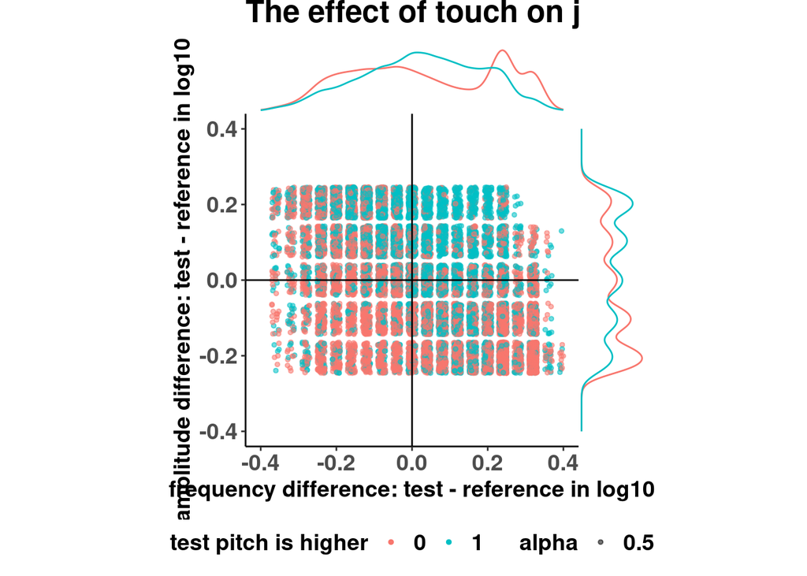

```r
# all ref frequencies
gp25 <- ggplot(tdat, aes(y = d_amp, x = d_freq, colour = factor(correct))) +
  geom_jitter(width = 0.01, size = 1, aes(alpha=0.5)) +
  geom_vline(xintercept = 0, colour = "black") +
  geom_hline(yintercept = 0, colour = "black") +
  labs(title = "The effect of touch on judgement",
       y = "amplitude difference: test - reference in log10",
       x = "frequency difference: test - reference in log10",
       color='test pitch is higher') +
  ylim(c(-0.4, 0.4)) +
  xlim(c(-0.4, 0.4)) +
  coord_fixed() +
  theme_classic() +
  theme(legend.position = "bottom",
        title = element_text(size=16,face="bold"),
        axis.title=element_text(size=14,face="bold"),
        axis.text = element_text(size=14,face="bold"),
        legend.title = element_text(size=14,face="bold"),
        legend.text = element_text(size=14,face="bold"))
ggMarginal(gp25,
           groupColour = TRUE,
           groupFill = FALSE)
```

```r
pdf("amp_on_judge_pooled.pdf", width = 10, height = 10)
ggMarginal(gp25,
           groupColour = TRUE,
           groupFill = FALSE)
dev.off()
```

#### 確証的分析（CDA） 一般化線形混合モデル（GLMM）

生データである反応のEDAによって、観察者のピッチ弁別は周波数と振幅の対数の線形和で予測できそうなことがわかりました。以下、これをGLMMを用いて統計的に確証します。線形モデリングやランダム効果に関しては、ご自身で勉強する必要があると思います。スタンドフォード認知心理の[講義レジュメ](https://psych252.github.io/psych252book/)や[岩波データサイエンスのシリーズ本](https://www.iwanami.co.jp/book/b258169.html)がおすすめです。

lme4パッケージのglmer関数を使います。第一引数がモデルの式です。観察者の2択反応 correctを対数軸上の周波数差（d_freq）と振幅差（d_amp）とそれらの交互作用（d_freq:d_amp）で説明するモデルです。振幅の効果が周波数に依存するか否か（上記のEDAでは大差はないようだった）を判断するために、交互作用を追加しています。加えて、ランダム効果として、ランダム切片（1|sub, 反応バイアスの個人差）とランダム傾き（d_freq|sub,d_amp|sub：周波数（振幅）の影響の個人差）をいれています。ここでは周波数と振幅の交互作用に関してはランダム効果にいれていません。

```r
###############################################
# Confirmatory data analysis
# the effect of amp. on judgement
#
# logistic regression
# generalized linear mixed effects models
# base model
m1 <- glmer(correct ~  d_freq + d_amp + d_freq:d_amp +
        + (1|sub)
        + (-1+d_freq|sub)
        + (-1+d_amp|sub),
        data = tdat,
        family = binomial,
        na.action = "na.fail",
        control = glmerControl(optimizer = "bobyqa"))
summary(m1)
```

```
## Generalized linear mixed model fit by maximum likelihood (Laplace
##   Approximation) [glmerMod]
##  Family: binomial  ( logit )
## Formula: correct ~ d_freq + d_amp + d_freq:d_amp + +(1 | sub) + (-1 +
##     d_freq | sub) + (-1 + d_amp | sub)
##    Data: tdat
## Control: glmerControl(optimizer = "bobyqa")
##
##       AIC       BIC    logLik -2*log(L)  df.resid
##   21149.2   21203.6  -10567.6   21135.2     17363
##
## Scaled residuals:
##     Min      1Q  Median      3Q     Max
## -4.5094 -0.8152 -0.4178  0.9288  4.0474
##
## Random effects:
##  Groups Name        Variance Std.Dev.
##  sub    (Intercept)  0.05483 0.2342
##  sub.1  d_freq      13.74577 3.7075
##  sub.2  d_amp        7.21030 2.6852
## Number of obs: 17370, groups:  sub, 15
##
## Fixed effects:
##              Estimate Std. Error z value Pr(>|z|)
## (Intercept)   -0.1814     0.0635  -2.857  0.00428 **
## d_freq         4.1982     0.9494   4.422 9.78e-06 ***
## d_amp          5.1083     0.7028   7.268 3.64e-13 ***
## d_freq:d_amp  10.7632     0.7158  15.037  < 2e-16 ***
## ---
## Signif. codes:  0 '***' 0.001 '**' 0.01 '*' 0.05 '.' 0.1 ' ' 1
##
## Correlation of Fixed Effects:
##             (Intr) d_freq d_amp
## d_freq      -0.005
## d_amp       -0.008  0.011
## d_freq:d_mp  0.142  0.012 -0.003
```

分散分析のようにカイ2乗検定で各予測変数の統計的優位性を確認します。

```r
(jt_m1<-joint_tests(m1))
```

```
##  model term   df1 df2 F.ratio   Chisq p.value
##  d_freq         1 Inf  18.122  18.122  <.0001
##  d_amp          1 Inf  61.030  61.030  <.0001
##  d_freq:d_amp   1 Inf 226.111 226.111  <.0001
```

今度は、情報量基準を用いたモデル比較の枠組みで交互作用の有無を検討してみます。ベストモデルは最上位に示され、交互作用を含んでいます。交互作用を含まないモデルとのAICの差(delta)は大きく(223.64)、交互作用は確かにあると言えます（deltaの大小については、コメントを読んでください）。

```r
# model comparison with reduced models
# AIC: akaike's information criteria
# Δi=AICi−AICmin,
#  where AICi is the AIC of the i-th model, and AICmin is the lowest AIC one obtains among the set of models examined (i.e., the prefered model).
#
# The rule of thumb, outlined e.g. in Burnham & Anderson 2004, is:
#   if Δi<2, then there is substantial support for the i-th model (or the evidence against it is worth only a bare mention),
#            and the proposition that it is a proper description is highly probable;
# if 2<Δi<4, then there is strong support for the i-th model;
# if 4<Δi<7, then there is considerably less support for the i-th model;
# models with Δi>10 have essentially no support.
# https://psycnet.apa.org/record/2004-20150-004
dredge(m1)
```

```
## Fixed term is "(Intercept)"
```

```
## Global model call: glmer(formula = correct ~ d_freq + d_amp + d_freq:d_amp + +(1 |
##     sub) + (-1 + d_freq | sub) + (-1 + d_amp | sub), data = tdat,
##     family = binomial, control = glmerControl(optimizer = "bobyqa"),
##     na.action = "na.fail")
## ---
## Model selection table
##     (Int) d_amp d_frq d_amp:d_frq df    logLik    AICc  delta weight
## 8 -0.1814 5.108 4.198       10.76  7 -10567.62 21149.3   0.00      1
## 4 -0.3230 5.249 4.057              6 -10680.44 21372.9 223.64      0
## 2 -0.3218 5.232                    5 -10686.33 21382.7 233.40      0
## 3 -0.3235       4.059              5 -10691.16 21392.3 243.08      0
## 1 -0.3223                          4 -10697.06 21402.1 252.87      0
## Models ranked by AICc(x)
## Random terms (all models):
##   1 | sub, -1 + d_freq | sub, -1 + d_amp | sub
```

最後に、交互作用の様相を見てみます。

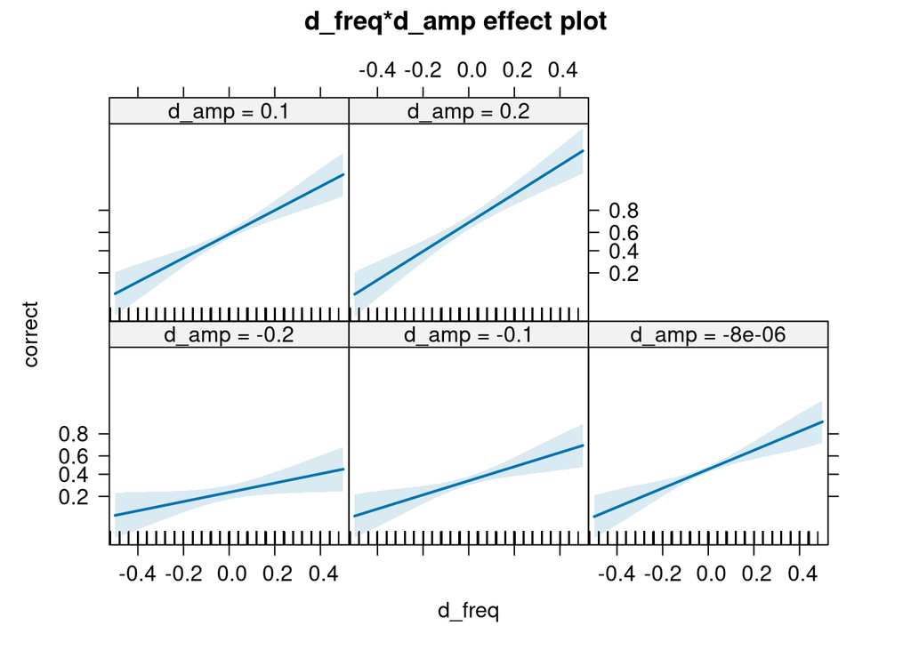

```r
eff <- allEffects(m1)
plot(eff)
```